# Plotting FTIR Spectra

Philip Bulsink

(Version français ci-dessous)

## Introduction to PlotFTIR

Many chemists use Fourier Transform Infra-red spectroscopy (FTIR) to analyze chemicals and materials in their laboratories. They may test for purity, composition of mixtures, changes in functional groups, or evaluate other properties. These spectra are sometimes included in journal articles but, as of yet, R has not had a convenient tool for plotting spectra.

In this document we’ll be using the built-in data in the `PlotFTIR` package to demonstrate loading data, modifying it, and plotting the resulting spectra. While the package doesn’t have raw data files, we will simulate this portion by reading the built-in data from disk.

## Installing PlotFTIR

To read FTIR files into R, the `PlotFTIR` package must be installed and loaded. Installation of the stable version of the package can be from CRAN.

```r
install.packages("PlotFTIR")
```

If you want to install the development version of this package, this can be done using the `devtools` package:

```r
devtools::install_github("NRCan/PlotFTIR")
```

Once installed by any method, the package needs to be activated in R before use.

```r
library(PlotFTIR)
```

## Reading Data

This document presumes you have FTIR spectra files in .csv, .txt (comma delimited), or .asp format. Additional file types may be supported in the future. We can read files individually using the `read_ftir()` function, or (as we’re about to do) you can read any number of files in a directory. Our data is stored in a `file_directory` variable, but you can provide your own location (such as “C:/Users/[userid]/FTIR/Data” or wherever your files are stored).

```r
spectra <- read_ftir_directory(
  path = file_directory,
  files = c("toluene.csv", "heptanes.csv", "isopropanol.csv", "paper.csv", "polystyrene.csv"),
  sample_names = c("toluene", "heptanes", "isopropanol", "paper", "polystyrene")
)

head(spectra)
```

```
#>   wavenumber absorbance sample_id
#> 1   650.4205   0.011155   toluene
#> 2   652.2841   0.002671   toluene
#> 3   654.1478   0.024340   toluene
#> 4   656.0115   0.066932   toluene
#> 5   657.8751   0.065699   toluene
#> 6   659.7388   0.061379   toluene
```

Having loaded the data, we can see that it has a structure of three columns, named `wavenumber`, `absorbance` and `sample_id`. We’ve read a few files in so all of the spectra are included in the one `spectra` object.

## Plotting

The loaded spectra can be plotted (with reasonable defaults) in just one line of code:

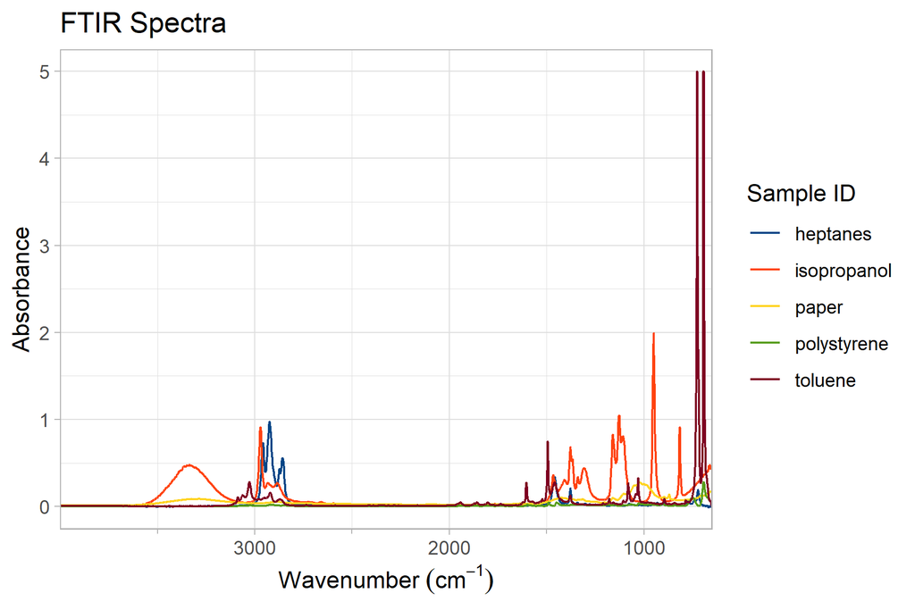

```r
plot_ftir(spectra)
```

If plotting multiple samples (as we are here), you can offset the samples in the y axis to be able to more clearly see differences where they may have otherwise overlapped near the baseline:

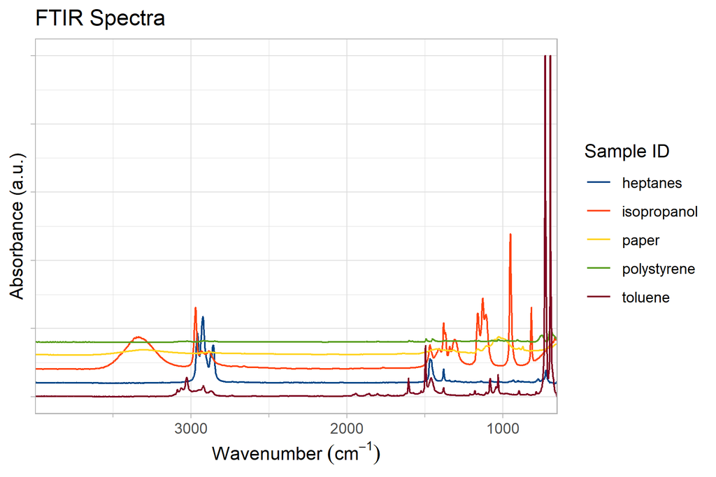

```r
plot_ftir_stacked(spectra)
```

We can modify this plot a number of ways:

### Title & Subtitle

The plot title and subtitle, and the legend title are all customization. The location of the legend can be changed too! To add a subtitle, pass a two-element string vector to the `plot_title` argument of `plot_ftir()`.

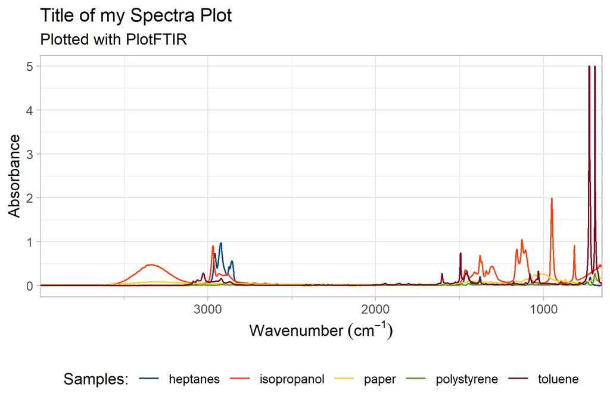

```r
plot_ftir(spectra, plot_title = c("Title of my Spectra Plot", "Plotted with PlotFTIR"), legend_title = "Samples:") |>
  move_plot_legend(position = "bottom")
```

### Rename the Plotted Samples

Once a plot has been produced, it’ easy to rename the samples in the legend. This might be useful when moving from exploratory analysis to a final output product, or if the sample names in the raw data are very long and you have short-forms that you want to show on the plot. The format for the renaming is `"new_name"` = `"old_name"`. Not all `sample_id` need to be matched, samples without a rename given will retain the name they currently have.

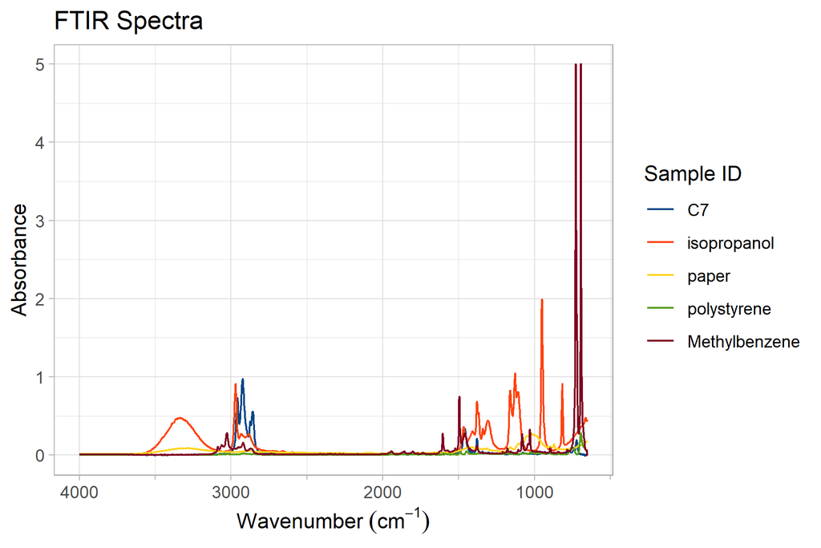

```r
plot_ftir(spectra) |>
  rename_plot_sample_ids(sample_ids = c("Methylbenzene" = "toluene", "C7" = "heptanes"))
```

### Compress Low Energy Region

The lower energy region of a FTIR plot may not be of much interest. We can compress those to both save graphical space and enhance the view of the more complex fingerprint region at higher energy.

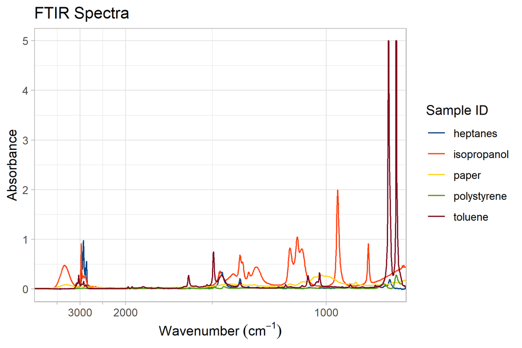

```r
plot_ftir(spectra) |>
  compress_low_energy(cutoff = 1850, compression_ratio = 5)
```

> You’ll see the usage of `|>` - this indicates that the output of this command is being passed to the first argument of the next command. More information on the pipe can be found in the valuable book [R for Data Science (2e)](https://r4ds.hadley.nz/workflow-style.html#sec-pipes) by Hadley Wickham, Mine Çetinkaya-Rundel, and Garrett Grolemund. Alternatively you can capture the output of each line of code in a variable and pass that variable on to the next function called.

### Limit Wavenumber Range

You can limit wavenumber range (zoom in) to any plot. If we want to look at the OH & CH stretch region, we can limit the spectra to that range.

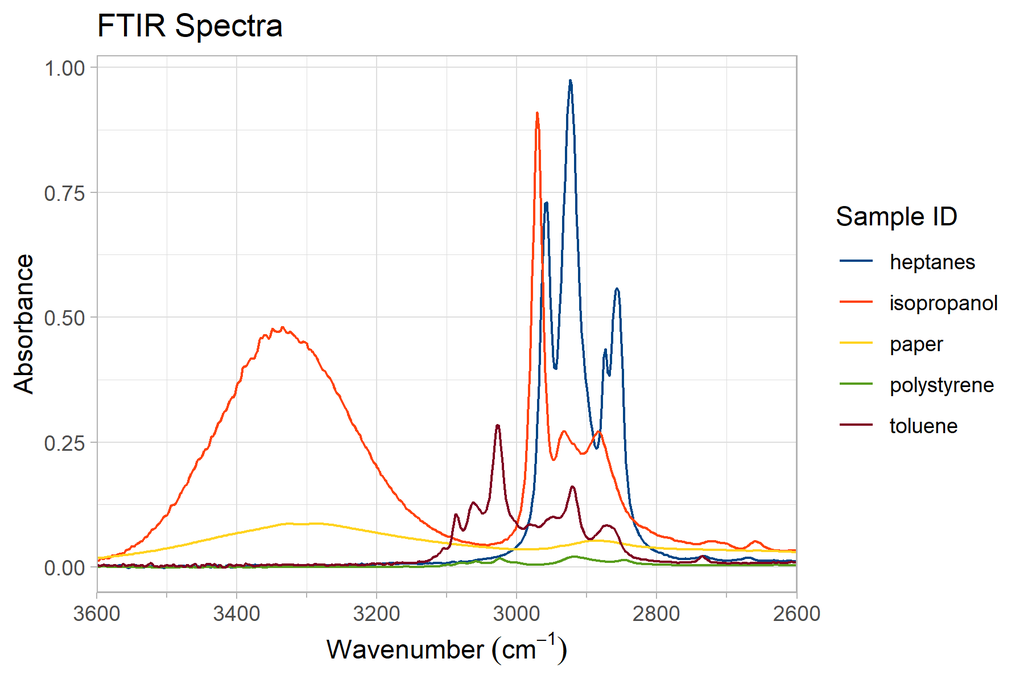

```r
plot_ftir(spectra) |>
  zoom_in_on_range(c(3600, 2600))
```

### Add Markers

We can add markers at any specific wavenumber, to indicate significant peaks or areas of interest. For example, the 1495 wavenumber peak corresponds with a carbon-carbon bond (aromatic) vibration. This marker’s label can be coloured or styled in any way, and the line can be modified as well. See the `ggplot2` documentation [for `line_aesthetics` and `label_aesthetics`](https://ggplot2.tidyverse.org/articles/ggplot2-specs.html).

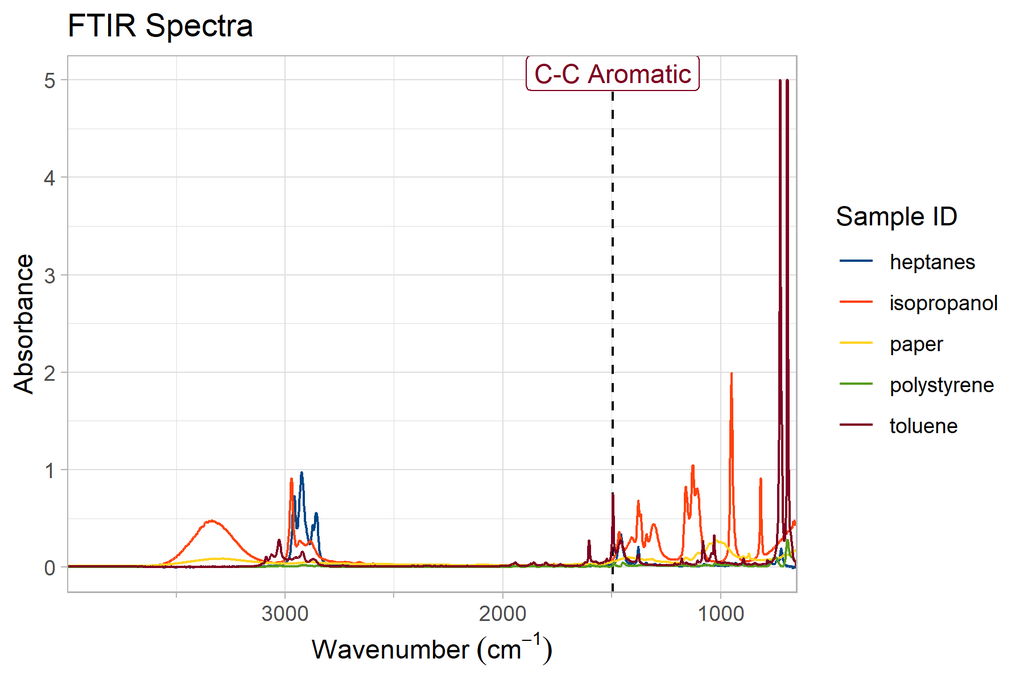

```r
plot_ftir(spectra) |>
  add_wavenumber_marker(
    wavenumber = 1495,
    text = "C-C Aromatic",
    line_aesthetics = list("linetype" = "dashed"),
    label_aesthetics = list("color" = "#7e0021")
  )
```

Note that any number of markers can be added, before or after other transformations of the spectral plot. The text of multiple markers may overlap.

### Putting It All Together

```r
plot_ftir(spectra, plot_title = c("My FTIR Plot", "Closeup of Detailed Region 1600 to 800 wavenumbers"), legend_title = "Samples:") |>
  move_plot_legend(position = "bottom") |>
  zoom_in_on_range(zoom_range = c(1600, 800)) |>
  add_wavenumber_marker(wavenumber = 1495, text = "C-C Aromatic", line_aesthetics = c(color = "#7e0021", linetype = "dotted")) |>
  add_wavenumber_marker(wavenumber = 817, text = "C-C-O\nsymmetric", line_aesthetics = c(color = "#ff420e", linetype = "dotted")) |>
  add_wavenumber_marker(wavenumber = 1380, text = "CH3", line_aesthetics = c(linetype = "dashed")) |>
  rename_plot_sample_ids(c("C7 Alkane" = "heptanes", "2-Propanol" = "isopropanol", "Toluene" = "toluene"))
```

```
#> Error in `add_wavenumber_marker()`:
#> ! Error in `PlotFTIR::add_wavenumber_marker()`. `line_aesthetics` must
#>   be a named list. You provided a character vector.
```

## Mathematical modifications

### Conversion Between Transmittance and Absorbance

Some instruments collect data in transmittance units, others in absorbance units. It could also be required to plot FTIR spectra in some specific units for a journal or report, or to compare to other existing literature. Fortunately, the two are related by a simple mathematical function. Two functions exist in this package to easily swap between the two y-axis units. We’ll use `absorbance_to_transmittance()` but the inverse `transmittance_to_absorbance()` is available as well.

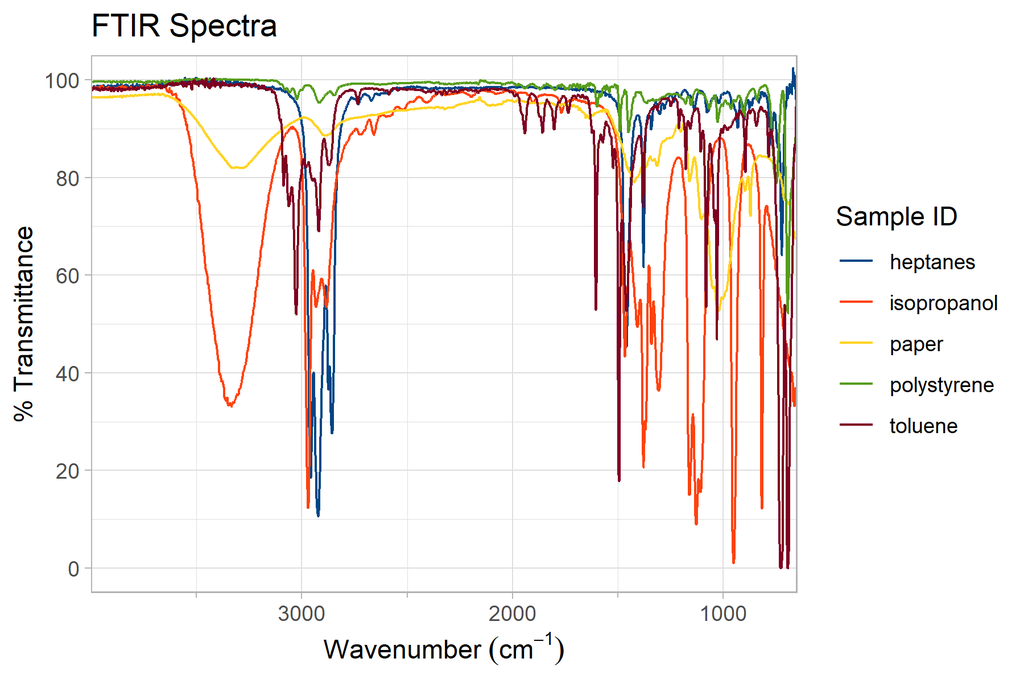

```r
transmittance_spectra <- absorbance_to_transmittance(spectra)

plot_ftir(transmittance_spectra)
```

### Adding or Subtracting Numerical Values

It may be desired to shift a sample’s result on the plotted spectra by a certain numerical amount. This can be done by adding or subtracting a `scalar` value - a single value of a set magnitude. We can use the `add_scalar_value()` or `subtract_scalar_value()` function to do that addition or subtraction to the data prior to plotting. These functions can act on all the spectra in the data set, or only on specific sample_ids as provided.

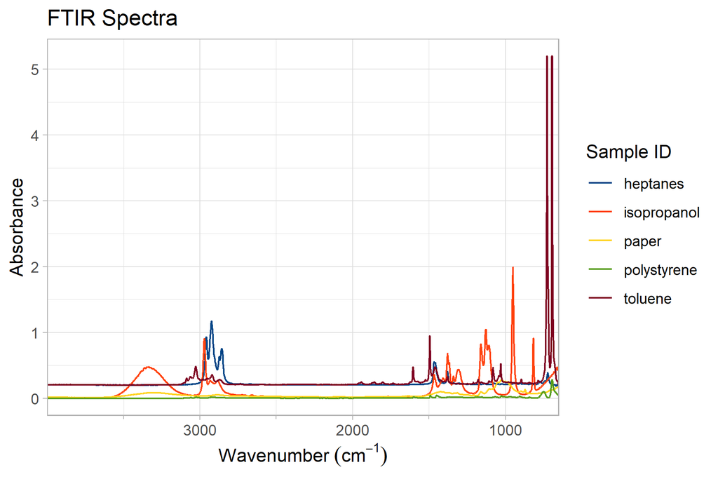

```r
shifted_spectra <- add_scalar_value(ftir = spectra, value = 0.2, sample_ids = c("heptanes", "toluene"))

plot_ftir(shifted_spectra)
```

Note that just the heptanes and toluene are shifted!

### Averaging Multiple Spectra

Sometimes you may have analyzed samples in replicate and wish to average their results together. In this situation, it may be easier to see an average of the spectra instead of all of those available. Our sample spectra doesn’t include any replecate analysis, but this can be performed by calling `average_spectra()`. This returns a `data.frame` which includes *only* the resulting average, even if you’ve only averaged a few of the samples (this is important to note, because if we averaged `"toluene"` and `"heptanes"` from the sample spectra set, the resulting data.frame wouldn’t include `"isopropanol"`, `"paper"` or `"polystyrene"` spectra, so they would be lost by this process).

### Shift Baselines

It’s possible to adjust baselines by a few different mechanisms in `PlotFTIR.` The baseline can be adjusted at a single point (i.e. set that point to 0 absorbance or 100 transmittance and shift the rest of the spectra accordingly), at a minimum (or maximum for transmittance) across a certain range, or the whole spectra, or by an average of values across a range.

This can be done on a single sample in the data set, on each sample individually (where the amount of shift could be different for each sample), or the amount of baseline shift can be applied to all of the samples at once (i.e. where the same shift is applied to all of the samples).

All of these shifts are achieved by calling the `recalculate_baseline()` function.

For this demonstration, we’ll use the `biodiesel` data contained in the package. It’s a set of spectra of diesel samples containing increasing amount of biodiesel.

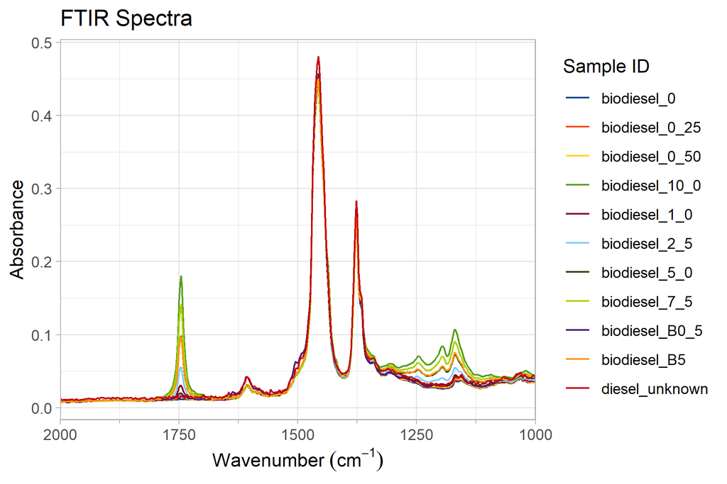

```r
plot_ftir(biodiesel) |>
  zoom_in_on_range(c(2000, 1000))
```

If you look closely, all of the spectra are floating just above the 0 absorbance line. We can adjust those down then plot the same. We’ll recalculate based on the average (`method = "average"`) across the `wavenumber_range = c(2000, 1900)`, and move all of the samples by their own calculated amount (i.e. `individually = TRUE`).

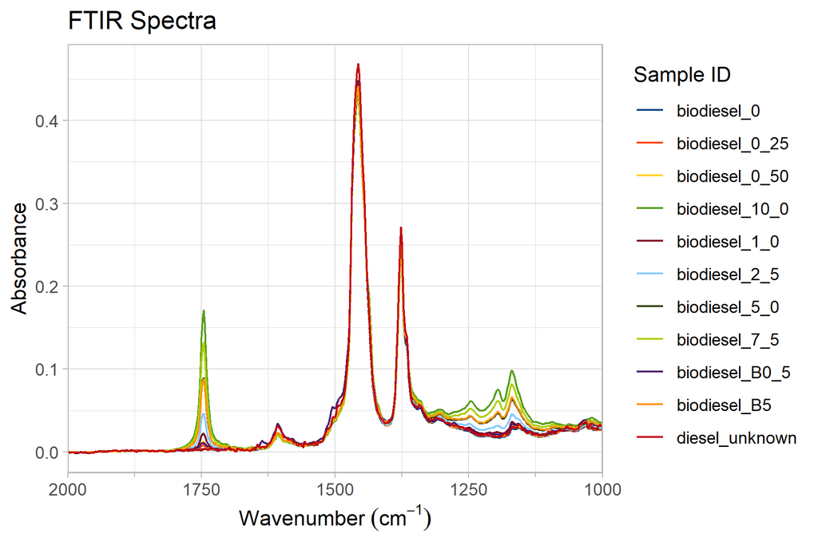

```r
biodiesel |>
  recalculate_baseline(method = "average", wavenumber_range = c(2000, 1900), individually = TRUE) |>
  plot_ftir() |>
  zoom_in_on_range(c(2000, 1000))
```

Of course, if you aren’t careful with baselining you can get some weird results. If we didn’t pay attention and tried to adjust by the point at 1250 cm-1 individually, we’d get a plot that’s not useful in most situations (even if it looks cool).

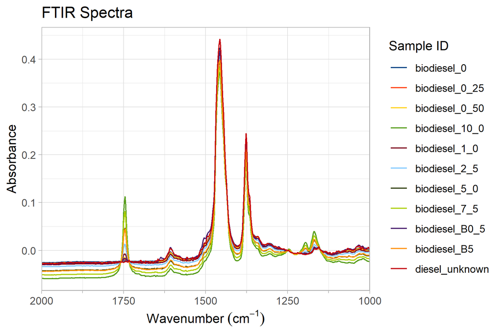

```r
biodiesel |>
  recalculate_baseline(method = "point", wavenumber_range = 1250, individually = TRUE) |>
  plot_ftir() |>
  zoom_in_on_range(c(2000, 1000))
```

Instead, it might be more useful to adjust all of the spectra by the minimum point in a range (the minimum of each sample’s minimum in the range). This puts that region close to zero, without removing what might be otherwise useful differences in absorbance.

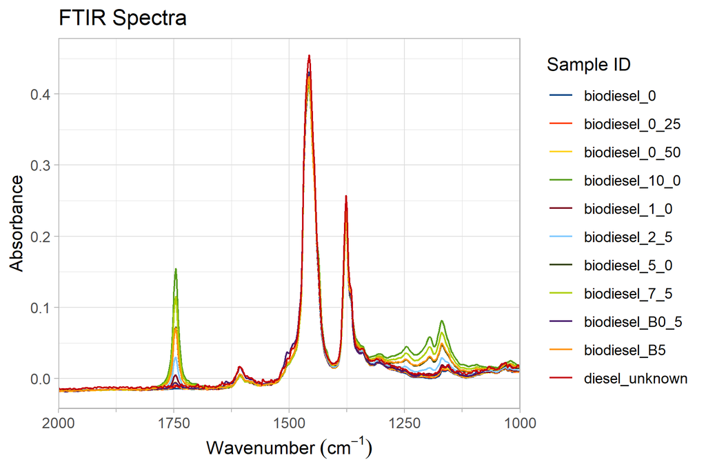

```r
biodiesel |>
  recalculate_baseline(method = "minimum", wavenumber_range = c(1300, 1000), individually = FALSE) |>
  plot_ftir() |>
  zoom_in_on_range(c(2000, 1000))
```

## Saving Spectral Plots

The `PlotFTIR` package contains convenient functions for saving spectra plots to disk. This wraps the `ggplot2` graphics package function, so much more specific information can be found [in their documentation](https://ggplot2.tidyverse.org/reference/ggsave.html). Options for filetypes include “eps”, “ps”, “tex” (pictex), “pdf”, “jpeg”, “tiff”, “png”, “bmp”, “svg” or “wmf” (on windows only). More options as described in the documentation for `ggplot::ggsave()` above can be passed to the function to tune your output file (options such as resolution, size, etc.).

```r
biodiesel |>
  ploft_ftir() |>
  save_plot(filename = "my_ftir_plot.png", filetype = ".png")
```

# Tracé de spectres IRTF

## Introduction à PlotFTIR

De nombreux chimistes utilisent la spectroscopie infrarouge à transformée de Fourier (IRTF) pour analyser les produits chimiques et les matériaux dans leurs laboratoires. Ils peuvent tester la pureté, la composition des mélanges, les changements dans les groupes fonctionnels ou évaluer d’autres propriétés. Ces spectres sont parfois inclus dans des articles de journaux mais, jusqu’à présent, R ne dispose pas d’un outil pratique pour tracer les spectres.

Dans ce document, nous utiliserons les données intégrées dans le package `PlotFTIR` pour démontrer le chargement des données, leur modification et le tracé des spectres résultants. Bien que le paquetage ne dispose pas de fichiers de données brutes, nous simulerons cette partie en lisant les données intégrées à partir du disque.

## Installation de PlotFTIR

Pour lire les fichiers IRTF dans R, le package `PlotFTIR` doit être installé et chargé. L’installation de la version stable du package peut se faire à partir de CRAN.

```r
install.packages("PlotFTIR")
```

Si vous souhaitez installer la version de développement de ce package, vous pouvez le faire en utilisant le package `devtools`:

```r
devtools::install_github("NRCan/PlotFTIR")
```

Une fois installé (par n’importe quelle méthode), le package doit être activé dans R avant utilisation.

```r
library(PlotFTIR)
```

## Lecture des données

Ce document suppose que vous disposez de fichiers de spectres IRTF au format .csv, .txt (délimité par des virgules) ou .asp. D’autres types de fichiers pourront être pris en charge à l’avenir. Nous pouvons lire les fichiers individuellement en utilisant la fonction `read_ftir()`, ou (comme nous allons le faire) vous pouvez lire n’importe quel nombre de fichiers dans un répertoire. Nos données sont stockées dans une variable `file_directory`, mais vous pouvez fournir votre propre emplacement (comme “C:/Users/[userid]/FTIR/Data” ou tout autre endroit où vos fichiers sont stockés).

```r
spectres <- read_ftir_directory(
  path = file_directory,
  files = c("toluene.csv", "heptanes.csv", "isopropanol.csv", "paper.csv", "polystyrene.csv"),
  sample_names = c("toluene", "heptanes", "isopropanol", "paper", "polystyrene")
)

head(spectres)
```

```
#>   wavenumber absorbance sample_id
#> 1   650.4205   0.011155   toluene
#> 2   652.2841   0.002671   toluene
#> 3   654.1478   0.024340   toluene
#> 4   656.0115   0.066932   toluene
#> 5   657.8751   0.065699   toluene
#> 6   659.7388   0.061379   toluene
```

Après avoir chargé les données, nous pouvons voir qu’elles ont une structure de trois colonnes, nommées `wavenumber`, `absorbance` et `sample_id`. Nous avons lu quelques fichiers, donc tous les spectres sont inclus dans un seul objet `spectres`.

## Plotting

Les spectres chargés peuvent être tracés (avec des valeurs par défaut raisonnables) en une seule ligne de code (notez que l’ajout de `lang = 'fr'` produit un tracé avec des titres français):

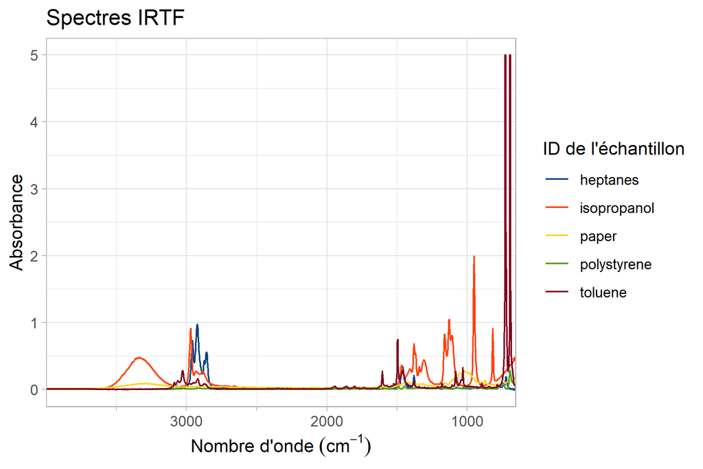

```r
plot_ftir(spectres, lang = "fr")
```

Si vous tracez plusieurs échantillons (comme nous le faisons ici), vous pouvez décaler les échantillons sur l’axe des y pour pouvoir voir plus clairement les différences là où ils auraient pu se chevaucher près de la ligne de base:

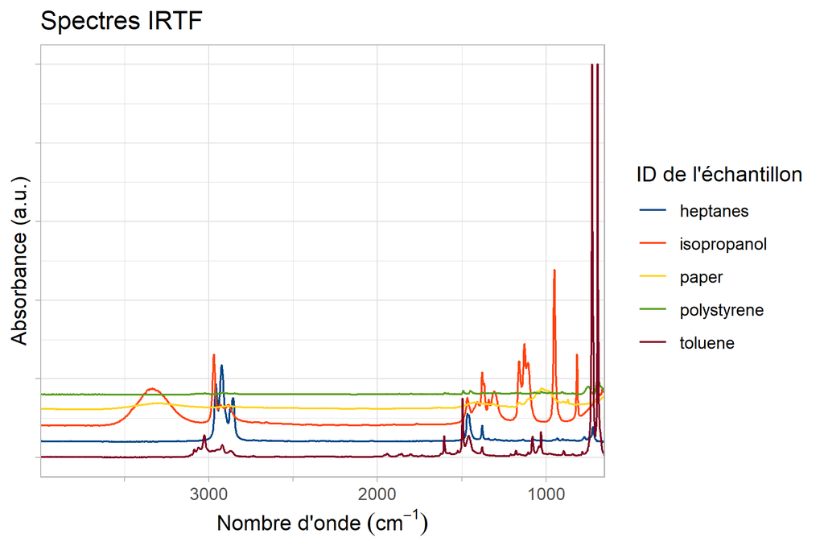

```r
plot_ftir_stacked(spectres, lang = "fr")
```

Nous pouvons modifier ce tracé de plusieurs manières:

### Titre & Sous-titre

Le titre et le sous-titre du tracé, ainsi que le titre de la légende sont tous configurables. L’emplacement de la légende peut également être modifié ! Pour ajouter un sous-titre, passez un vecteur de texte à deux éléments à l’argument `plot_title` de `plot_ftir()`.

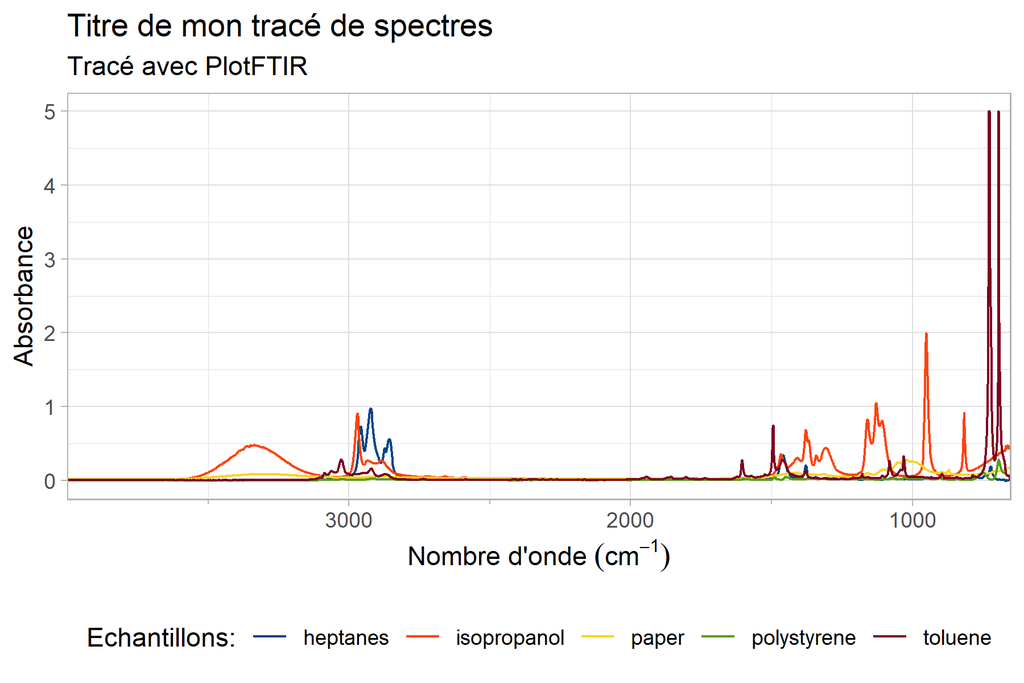

```r
plot_ftir(spectres, lang = "fr", plot_title = c("Titre de mon tracé de spectres", "Tracé avec PlotFTIR"), legend_title = "Echantillons:") |>
  move_plot_legend(position = "bottom")
```

### Renommer les échantillons tracés

Lorsque le tracé a été produit, il est facile de renommer les échantillons dans la légende. Cela peut être utile pour passer d’une analyse exploratoire à un produit final, ou si les noms des échantillons dans les données sont très longs et que vous avez des formes abrégées que vous voulez montrer sur le tracé. Le format de renommage est `"nouveau_nom" = "ancien_nom"`. Il n’est pas nécessaire de faire correspondre tous les `sample_id`, les échantillons qui n’ont pas été renommés conserveront le nom qu’ils portent actuellement.

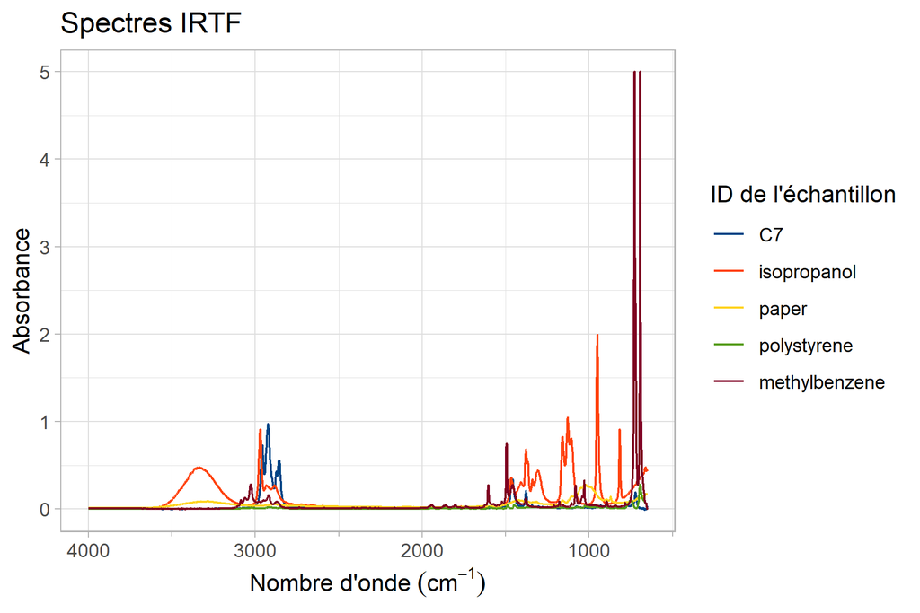

```r
plot_ftir(spectres, lang = "fr") |>
  rename_plot_sample_ids(sample_ids = c("methylbenzene" = "toluene", "C7" = "heptanes"))
```

### Compression de la région à faible énergie

La région de basse énergie d’un tracé IRTF peut ne pas présenter beaucoup d’intérêt. Nous pouvons les compresser pour économiser de l’espace graphique et améliorer la visualisation de la région plus complexe de l’empreinte digitale à plus haute énergie.

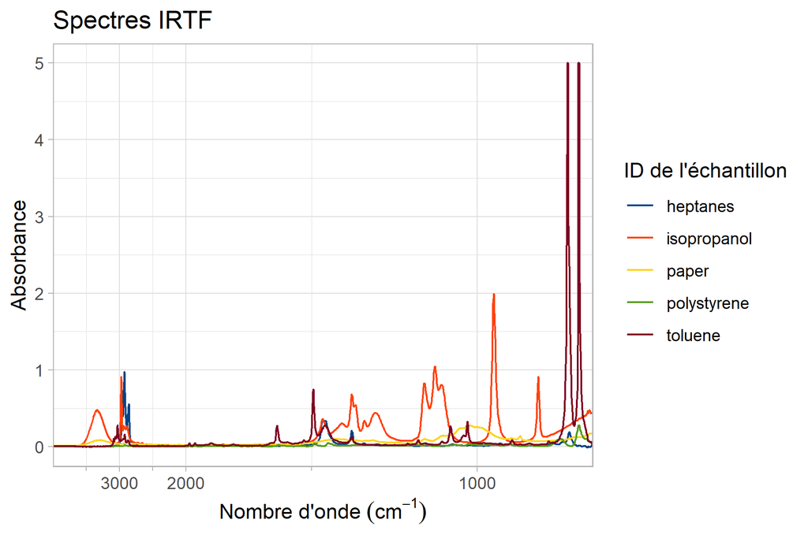

```r
plot_ftir(spectres, lang = "fr") |>
  compress_low_energy(cutoff = 1850, compression_ratio = 5)
```

> Vous verrez l’utilisation de `|>` - cela indique que la sortie de cette commande est transmise au premier argument de la commande suivante. Vous trouverez plus d’informations sur le pipe dans le livre [R for Data Science (2e)] (https://r4ds.hadley.nz/workflow-style.html#sec-pipes) de Hadley Wickham, Mine Çetinkaya-Rundel et Garrett Grolemund. Vous pouvez également capturer la sortie de chaque ligne de code dans une variable et transmettre cette variable à la prochaine fonction appelée.

### Limiter les nombres d’ondes indiqués

Vous pouvez limiter la gamme de nombres d’ondes (zoomer sur) à n’importe quel tracé. Si nous voulons examiner la région d’étirement OH & CH, nous pouvons limiter les spectres à cette gamme.

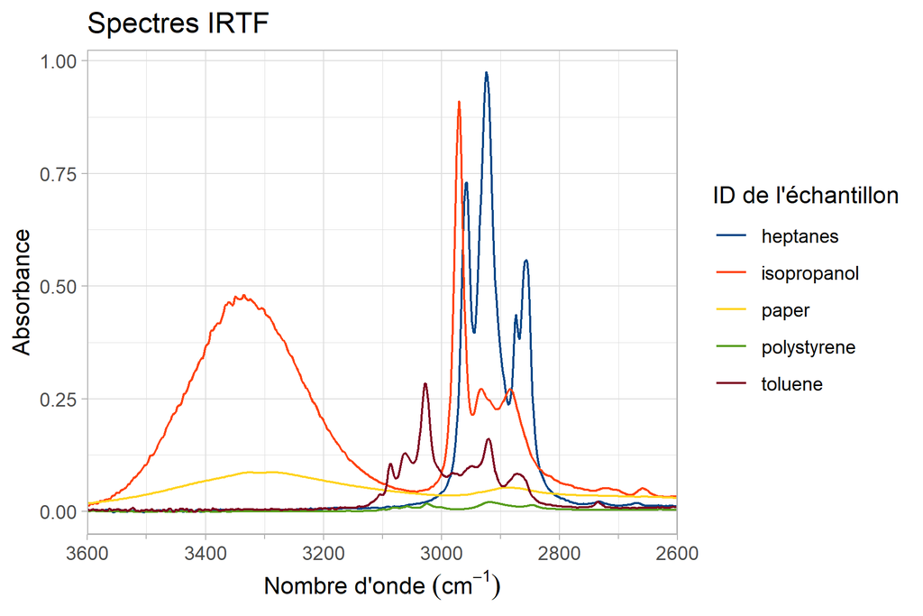

```r
plot_ftir(spectres, lang = "fr") |>
  zoom_in_on_range(c(3600, 2600))
```

### Ajouter des indicateurs

Nous pouvons ajouter des marqueurs à n’importe quel nombre d’ondes spécifique, pour indiquer les pics significatifs ou les zones d’intérêt. Par exemple, le nombre d’ondes de 1495 correspond à une vibration de liaison carbone-carbone (aromatique). L’étiquette de ce marqueur peut être colorée ou stylisée à volonté, et la ligne peut également être modifiée. Voir la documentation de `ggplot2` [pour `line_aesthetics` et `label_aesthetics`](https://ggplot2.tidyverse.org/articles/ggplot2-specs.html).

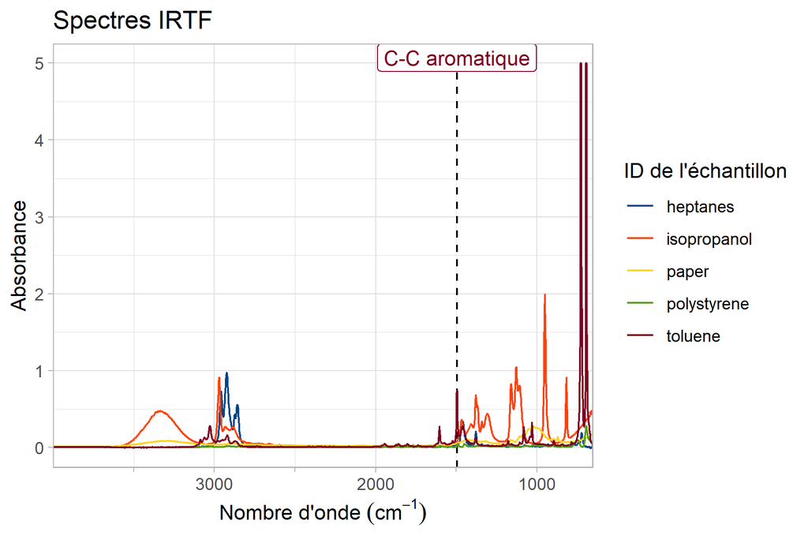

```r
plot_ftir(spectres, lang = "fr") |>
  add_wavenumber_marker(
    wavenumber = 1495,
    text = "C-C aromatique",
    line_aesthetics = list("linetype" = "dashed"),
    label_aesthetics = list("color" = "#7e0021")
  )
```

Notez qu’un nombre quelconque de marqueurs peut être ajouté, avant ou après d’autres transformations du tracé spectral. Le texte de plusieurs marqueurs peut se chevaucher.

### Mise en place de l’ensemble

```r
plot_ftir(spectres, lang = "fr", plot_title = c("Mon Tracé IRTF", "Gros plan de la région détaillée de 1600 à 800 nombres d'ondes"), legend_title = "Samples:") |>
  move_plot_legend(position = "bottom") |>
  zoom_in_on_range(zoom_range = c(1600, 800)) |>
  add_wavenumber_marker(wavenumber = 1495, text = "C-C aromatique", line_aesthetics = c(color = "#7e0021", linetype = "dotted")) |>
  add_wavenumber_marker(wavenumber = 817, text = "C-C-O\nsymétrique", line_aesthetics = c(color = "#ff420e", linetype = "dotted")) |>
  add_wavenumber_marker(wavenumber = 1380, text = "CH3", line_aesthetics = c(linetype = "dashed")) |>
  rename_plot_sample_ids(c("C7 alcane" = "heptanes", "2-Propanol" = "isopropanol", "Toluene" = "toluene"))
```

```
#> Error in `add_wavenumber_marker()`:
#> ! Error in `PlotFTIR::add_wavenumber_marker()`. `line_aesthetics` must
#>   be a named list. You provided a character vector.
```

## Modifications mathématiques

### Conversion entre la transmittance et l’absorbance

Certains instruments collectent des données en unités de transmittance, d’autres en unités d’absorbance. Il peut également être nécessaire de tracer les spectres IRTF dans certaines unités spécifiques pour une revue ou un rapport, ou pour les comparer à d’autres documents existants. Heureusement, les deux sont liés par une simple fonction mathématique. Deux fonctions existent dans ce package pour permuter facilement entre les deux unités de l’axe des ordonnées. Nous utiliserons `absorbance_to_transmittance()` mais la fonction inverse `transmittance_to_absorbance()` est également disponible.

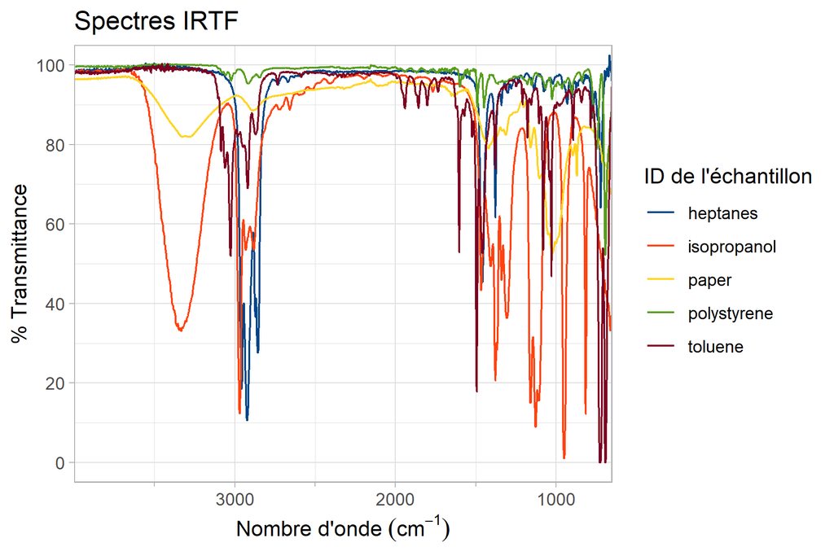

```r
spectres_transmittance <- absorbance_to_transmittance(spectres)
plot_ftir(spectres_transmittance, lang = "fr")
```

### Ajout ou soustraction de valeurs numériques

Il peut être souhaitable de décaler le résultat d’un échantillon sur les spectres tracés d’une certaine valeur numérique. Ceci peut être fait en ajoutant ou en soustrayant une valeur “scalaire” - une valeur unique d’une magnitude définie. Nous pouvons utiliser les fonctions `add_scalar_value()` ou `subtract_scalar_value()` pour effectuer cet ajout ou cette soustraction aux données avant de les tracer. Ces fonctions peuvent agir sur tous les spectres de l’ensemble de données, ou seulement sur des identifiants d’échantillons spécifiques.

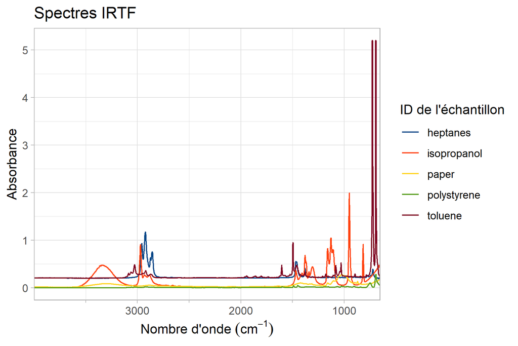

```r
spectres_decales <- add_scalar_value(ftir = spectres, value = 0.2, sample_ids = c("heptanes", "toluene"))

plot_ftir(spectres_decales, lang = "fr")
```

Notez que seuls les heptanes et le toluène sont décalés.

### Calcul de la moyenne de plusieurs spectres

Il peut arriver que vous ayez analysé des échantillons en double et que vous souhaitiez faire la moyenne de leurs résultats. Dans ce cas, il peut être plus facile de voir une moyenne des spectres au lieu de tous les spectres disponibles. Notre échantillon de spectres n’inclut pas d’analyse de réplétion, mais il est possible de le faire en appelant `average_spectra()`. Ceci renvoie un `data.frame` qui inclut *uniquement* la moyenne résultante, même si vous n’avez fait la moyenne que de quelques échantillons (il est important de le noter, car si nous faisons la moyenne des spectres `"toluène"` et `"heptanes"` de l’échantillon, le data.frame résultant n’inclurait pas les spectres `"isopropanol"`, `"papier"` ou `"polystyrène"`, donc ils seraient perdus par ce processus).

### Décaler les lignes de base

Il est possible d’ajuster les lignes de base par différents mécanismes dans `PlotFTIR.` La ligne de base peut être ajustée en un seul point (c.-à-d. fixer ce point à 0 absorbance ou 100 transmittance et décaler le reste des spectres en conséquence), à un minimum (ou un maximum pour la transmittance) sur une certaine gamme, ou sur l’ensemble des spectres, ou par une moyenne des valeurs sur une gamme.

Cette opération peut être effectuée sur un seul échantillon de l’ensemble de données, sur chaque échantillon individuellement (où l’ampleur du décalage peut être différente pour chaque échantillon), ou l’ampleur du décalage de la ligne de base peut être appliquée à tous les échantillons en même temps (c’est-à-dire que le même décalage est appliqué à tous les échantillons).

Tous ces changements sont réalisés en appelant la fonction `recalculate_baseline()`.

Pour cette démonstration, nous utiliserons les données `biodiesel` contenues dans le paquet. Il s’agit d’un ensemble de spectres d’échantillons de diesel contenant des quantités croissantes de biodiesel.

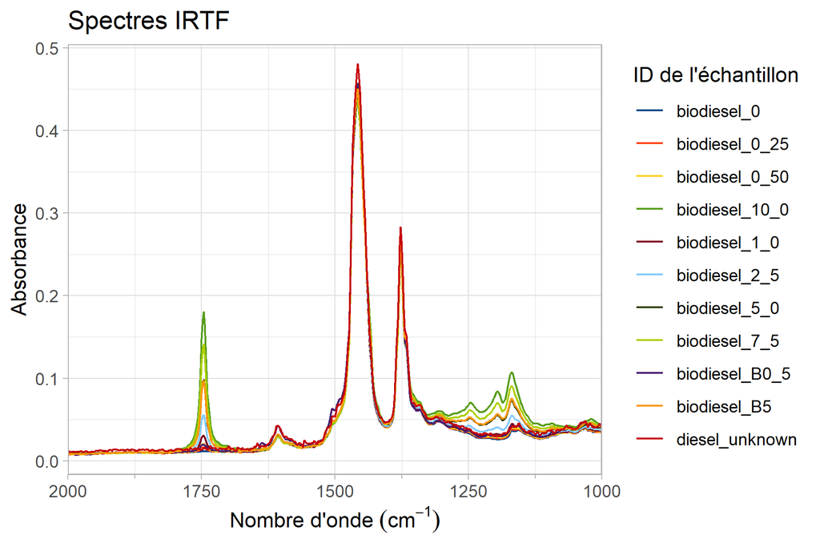

```r
plot_ftir(biodiesel, lang = "fr") |>
  zoom_in_on_range(c(2000, 1000))
```

Si vous regardez de près, tous les spectres flottent juste au-dessus de la ligne d’absorbance `0`. Nous pouvons les ajuster vers le bas puis tracer les mêmes. Nous allons recalculer sur la base de la moyenne (`method = "average"`) sur l’ensemble de `wavenumber_range = c(2000, 1900)`, et déplacer tous les échantillons de leur propre quantité calculée (c.-à-d. `individually = TRUE`).

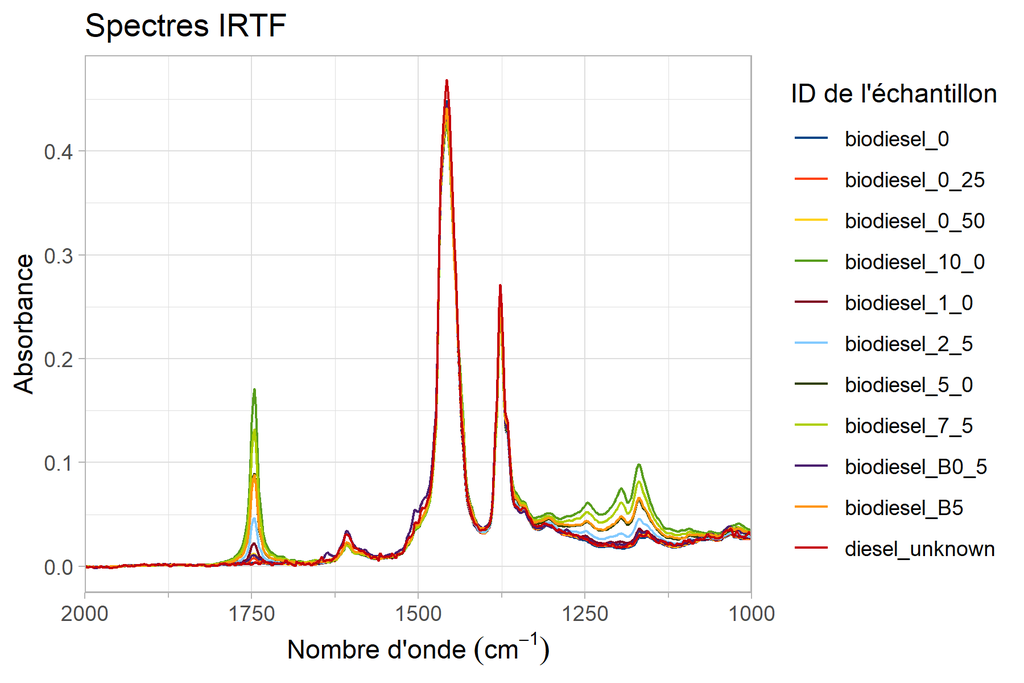

```r
biodiesel |>
  recalculate_baseline(method = "average", wavenumber_range = c(2000, 1900), individually = TRUE) |>
  plot_ftir(lang = "fr") |>
  zoom_in_on_range(c(2000, 1000))
```

Bien sûr, si l’on ne fait pas attention à l’alignement de base, on peut obtenir des résultats bizarres. Si nous ne faisions pas attention et essayions d’ajuster individuellement le point à 1250 cm-1, nous obtiendrions un tracé qui n’est pas utile dans la plupart des situations (même s’il a l’air cool).

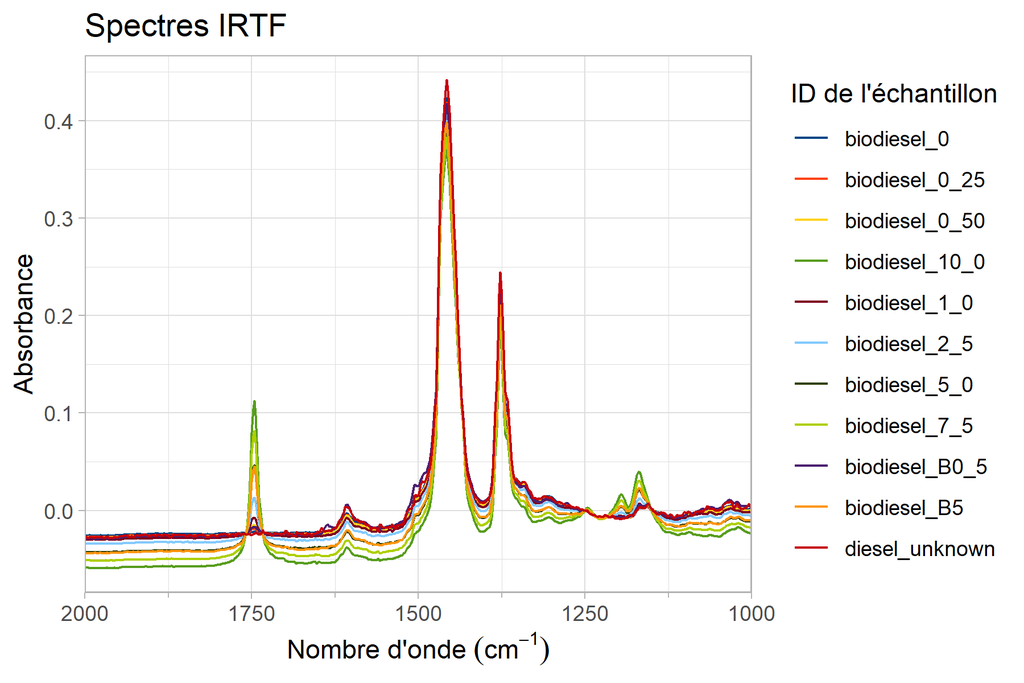

```r
biodiesel |>
  recalculate_baseline(method = "point", wavenumber_range = 1250, individually = TRUE) |>
  plot_ftir(lang = "fr") |>
  zoom_in_on_range(c(2000, 1000))
```

Il serait plus utile d’ajuster tous les spectres en fonction du point minimum d’une gamme (le minimum de chaque échantillon dans la gamme). Cela permet de rapprocher cette région de zéro, sans supprimer les différences d’absorbance qui pourraient être utiles.

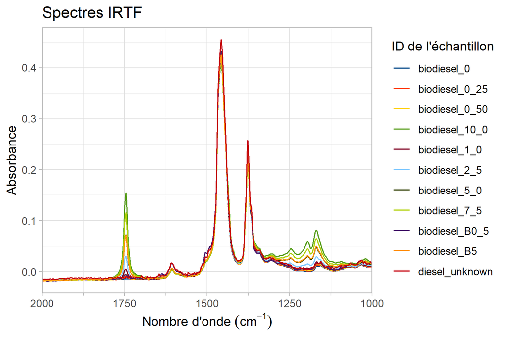

```r
biodiesel |>
  recalculate_baseline(method = "minimum", wavenumber_range = c(1300, 1000), individually = FALSE) |>
  plot_ftir(lang = "fr") |>
  zoom_in_on_range(c(2000, 1000))
```

## Sauvegarde des tracés spectraux

Le paquet `PlotFTIR` contient des fonctions pratiques pour sauvegarder les tracés de spectres sur le disque. Cette fonction reprend celle du paquet graphique `ggplot2`, de sorte que des informations plus spécifiques peuvent être trouvées [dans leur documentation] (https://ggplot2.tidyverse.org/reference/ggsave.html). Les options pour les types de fichiers incluent “eps,”ps”, “tex” (pictex), “pdf”, “jpeg”, “tiff”, “png”, “bmp”, “svg” ou “wmf” (sous Windows uniquement). D’autres options décrites dans la documentation de `ggplot::ggsave()` ci-dessus peuvent être passées à la fonction pour ajuster votre fichier de sortie (options telles que la résolution, la taille, etc.).

```r
biodiesel |>
  ploft_ftir() |>
  save_plot(filename = "mon_trace_irtf.png", filetype = ".png")
```